# analyze flow cytometry data from 2020-12-23

Bin He

2020-12-23

```r
require(tidyverse)
require(cowplot)
```

## Goal

This is to repeat the 2020-12-21 experiment.

## Material and methods

See gDoc. This time I reverted to one o/n growth. The second growth was done in the 96-well clear plate (not deep well). Cells were directly diluted into PBS and run on the flow cytometer.

### Table of strains

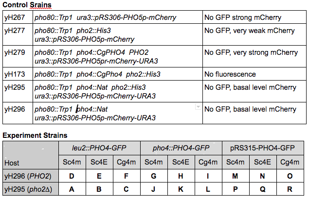

## Data and analysis

### Import data

```r
dat <- read_csv("20201223-Pho4-GFP-stats.csv")
dat <- dat %>% mutate(Pho4GFP = factor(Pho4GFP, levels = c("No-GFP","ScPho4-mNeon","ScPho4-EGFP", "CgPho4-mNeon")), Group = factor(Group, levels = c("control", "endogenous", "exogenous", "plasmid")), Pho4 = factor(Pho4, levels = c("pho4-","ScPho4", "CgPho4"))) %>% filter(Sample != "G2") # remove G2 as it most likely had multiple PHO5pr-mCherry integrated and causes the rest of the RFP data to be compressed
issues <- c("G3","B3","C1","C2","D1","E3") # see below for reasons
```

Looking at the detailed plots, I identified a few samples that are problematic.

lack *PHO5pr-mCherry*

two populations

too few cells collected

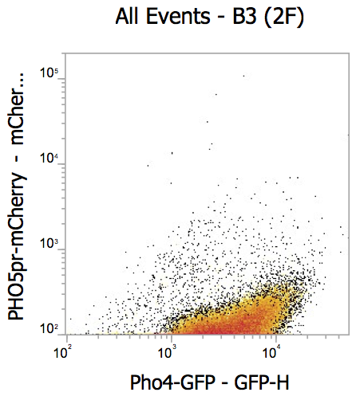

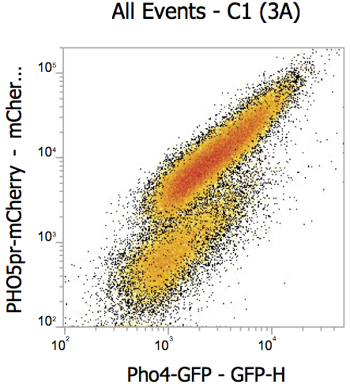

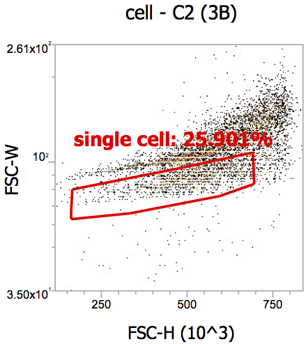

two populations

two populations

two populations

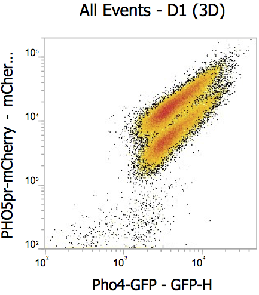

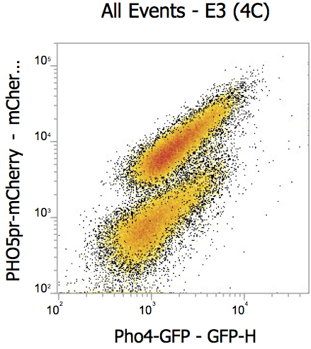

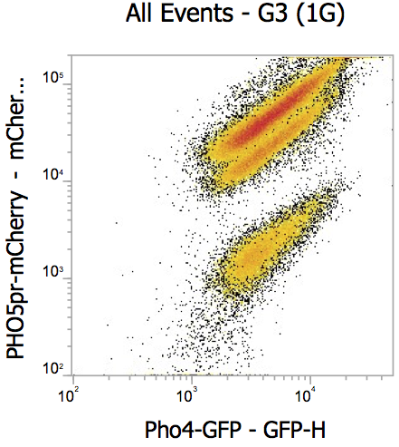